# Comparison of Classical Machine Learning Models for Colorectal Cancer Microbiome Classification

## 17.4 Multiclass Ranking Plot

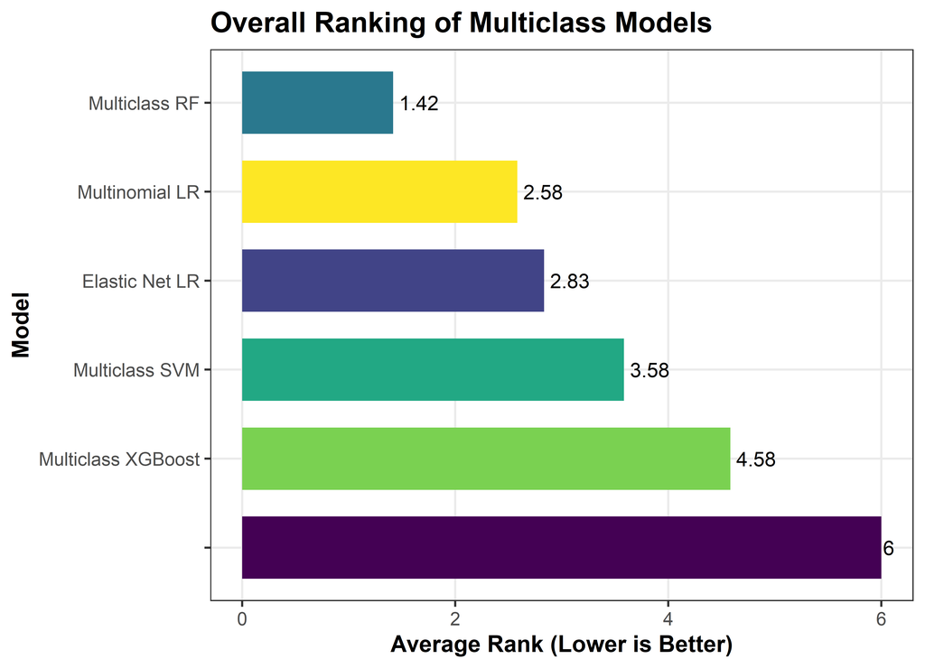

Average ranking of multiclass classification models across all reported performance metrics.

```r
ggplot(

multi_rank,

aes(

reorder(model,-AverageRank),

AverageRank,

fill=model

)

)+

geom_col(width=.70)+

geom_text(

aes(label=round(AverageRank,2)),

hjust=-0.15,

size=4

)+

coord_flip()+

scale_fill_viridis_d(option="D")+

labs(

title="Overall Ranking of Multiclass Models",

x="Model",

y="Average Rank (Lower is Better)"

)+

theme(

legend.position="none"

)
```

**Interpretation**

The multiclass ranking summarises classifier performance across all reported evaluation metrics. Because multiclass prediction is inherently more challenging than binary classification, the ranking should be interpreted within the multiclass setting only and should not be directly compared with the binary ranking.

## 17.5 Comparative Ranking of All Models

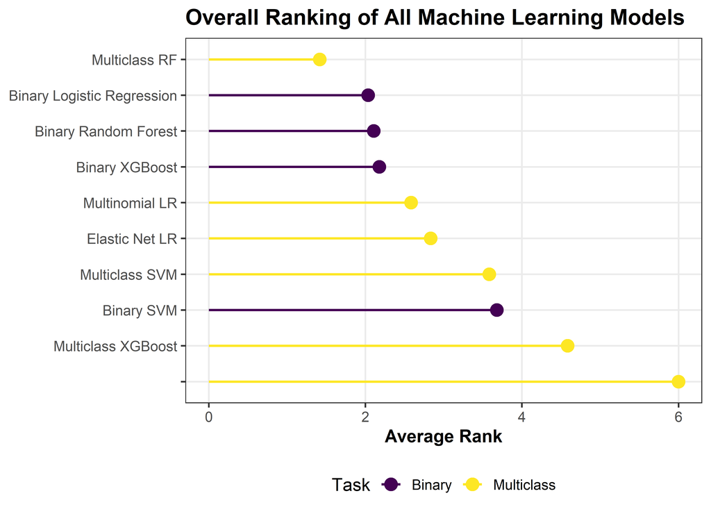

```r
binary_compare <-

binary_rank |>

transmute(

Model=model,

Task="Binary",

AverageRank

)

multi_compare <-

multi_rank |>

transmute(

Model=model,

Task="Multiclass",

AverageRank

)

overall_rank <-

bind_rows(

binary_compare,

multi_compare

)

ggplot(

overall_rank,

aes(

AverageRank,

reorder(Model,-AverageRank),

colour=Task

)

)+

geom_point(size=4)+

geom_segment(

aes(

x=0,

xend=AverageRank,

y=Model,

yend=Model

),

linewidth=0.8

)+

scale_colour_viridis_d(option="D")+

labs(

title="Overall Ranking of All Machine Learning Models",

x="Average Rank",

y=NULL

)
```

**Interpretation**

This lollipop plot provides a compact comparison of the overall ranking of all machine learning models evaluated in this study. Binary and multiclass models are displayed together for completeness; however, because the prediction tasks differ substantially in complexity, direct numerical comparisons between these groups should be interpreted cautiously.

## 17.6 Strengths and Weaknesses of Individual Models

[output not shown]

## 17.7 Summary

The overall ranking indicates that model selection should not rely solely on accuracy. Instead, classifiers demonstrating consistently strong performance across multiple complementary evaluation metrics are likely to provide greater robustness and improved generalisability when applied to independent microbiome datasets.

# 18 Consensus Microbial Biomarker Analysis

While each machine learning algorithm identified its own set of important microbial features, several taxa were consistently selected across multiple independent models. Rather than comparing raw importance values, which are algorithm-specific (e.g., regression coefficients, Gini importance, gain, or ROC importance), this section focuses on the consistency of biomarker selection across models.

Microbial taxa repeatedly identified by independent machine learning approaches are considered stronger candidate biomarkers because their predictive value is less dependent on the assumptions of a single classification algorithm.

# 19 Hyperparameter Optimisation Summary

Hyperparameter optimisation is a critical component of machine learning model development, enabling the identification of model configurations that maximise predictive performance while reducing the risk of overfitting. Across the evaluated models, hyperparameter tuning was performed using cross-validation procedures implemented within the `caret` framework, with model selection based primarily on the area under the receiver operating characteristic curve (AUC).

Summary of hyperparameter optimisation strategies used for the evaluated machine learning models.

| Model | Hyperparameters Optimised | Optimisation Strategy | Selection Metric |
| --- | --- | --- | --- |
| Binary Logistic Regression | None | Model fitting | AUC |
| Elastic Net Logistic Regression | alpha ~ “,” ~ lambda | Grid search | AUC |
| Multinomial Logistic Regression | None | Maximum likelihood estimation | AUC |
| Random Forest | mtry | Grid search | ROC AUC |
| Binary Random Forest | mtry | Grid search | ROC AUC |
| Support Vector Machine | C ~ “,” ~ sigma | Grid search | ROC AUC |
| Binary Support Vector Machine | C ~ “,” ~ sigma | Grid search | ROC AUC |
| XGBoost | eta, max_depth, gamma, min_child_weight, subsample, colsample_bytree | Grid search | ROC AUC |
| Binary XGBoost | eta, max_depth, gamma, min_child_weight, subsample, colsample_bytree | Grid search | ROC AUC |

### 19.0.1 Interpretation

The evaluated machine learning algorithms differed substantially in the number and complexity of hyperparameters requiring optimisation. Classical logistic regression models required little or no parameter tuning beyond model estimation, making them computationally efficient and highly interpretable. In contrast, Elastic Net regression required optimisation of both the mixing parameter (α) and regularisation parameter (λ), allowing simultaneous coefficient shrinkage and automatic feature selection.

Among the non-linear algorithms, Random Forest models primarily required optimisation of the number of predictor variables randomly sampled at each node (`mtry`), whereas Support Vector Machine models required simultaneous optimisation of the cost parameter (`C`) and kernel width (`σ`). XGBoost represented the most complex modelling approach, involving optimisation of multiple boosting parameters controlling learning rate, tree depth, regularisation, sampling strategy and tree complexity. Although these additional hyperparameters increase computational cost, they enable greater modelling flexibility and often improve predictive performance when appropriately tuned.

Overall, the use of systematic grid-search optimisation combined with repeated cross-validation ensured that each model was evaluated under an objective and reproducible optimisation framework.

## 19.1 Frequently Identified Biomarkers

Inspection of the feature importance analyses revealed several microbial taxa that were repeatedly selected across both binary and multiclass classification models.

[output not shown]

## 19.2 Consensus Biomarker Frequency

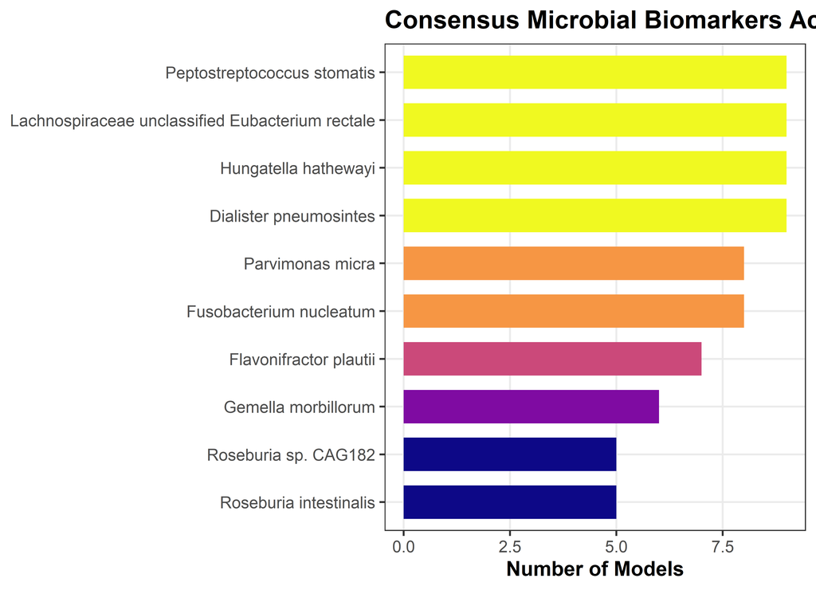

Frequency with which microbial biomarkers were selected across machine learning models.

```r
consensus_df <- tribble(
~Biomarker, ~Frequency,
"Peptostreptococcus stomatis",9,
"Dialister pneumosintes",9,
"Hungatella hathewayi",9,
"Lachnospiraceae unclassified Eubacterium rectale",9,
"Fusobacterium nucleatum",8,
"Parvimonas micra",8,
"Flavonifractor plautii",7,
"Gemella morbillorum",6,
"Roseburia intestinalis",5,
"Roseburia sp. CAG182",5
)

ggplot(consensus_df,
aes(reorder(Biomarker,Frequency),
Frequency,
fill=Frequency))+

geom_col(width=.7)+

coord_flip()+

scale_fill_viridis_c(option="C")+

labs(
title="Consensus Microbial Biomarkers Across Machine Learning Models",
x=NULL,
y="Number of Models"
)+

theme(legend.position="none")
```

**Interpretation**

Several microbial taxa were repeatedly identified by independent machine learning algorithms. The repeated selection of **Peptostreptococcus stomatis**, **Dialister pneumosintes**, **Hungatella hathewayi**, and **Lachnospiraceae unclassified Eubacterium rectale** suggests that these organisms represent robust biomarkers of colorectal cancer-associated microbial dysbiosis rather than artefacts of any particular modelling approach.